# Laboratorio 6 - Modelos de Regresión Logística

José Antón, Juan Fernando Menéndez, Fernando Mendoza

2026-04-17

# Actividad 1: Creación de variables dicotómicas

Muestra de las variables dicotómicas creadas

| price | categoria_precio | es_economica | es_intermedia | es_cara |
| --- | --- | --- | --- | --- |
| 97 | Economica | 1 | 0 | 0 |
| 160 | Intermedia | 0 | 1 | 0 |
| 38 | Economica | 1 | 0 | 0 |
| 145 | Intermedia | 0 | 1 | 0 |
| 58 | Economica | 1 | 0 | 0 |

En esta primera actividad, preparamos la información sobre los precios de las propiedades para que la computadora pueda procesarla en el nuevo algoritmo. Transformamos la categoría del precio en respuestas simples de “sí” o “no” representadas por el número uno y cero. Por ejemplo, en lugar de decirle al programa solamente que una propiedad es cara mediante texto, creamos una columna específica que marca con un uno si la vivienda es cara y con un cero si no lo es. Repetimos este mismo proceso para los alojamientos económicos y de precio intermedio. Este paso es indispensable porque los modelos de regresión logística que desarrollaremos a continuación son operaciones matemáticas que necesitan estos números exactos para calcular las probabilidades correctamente.

# Actividad 2: División de los datos

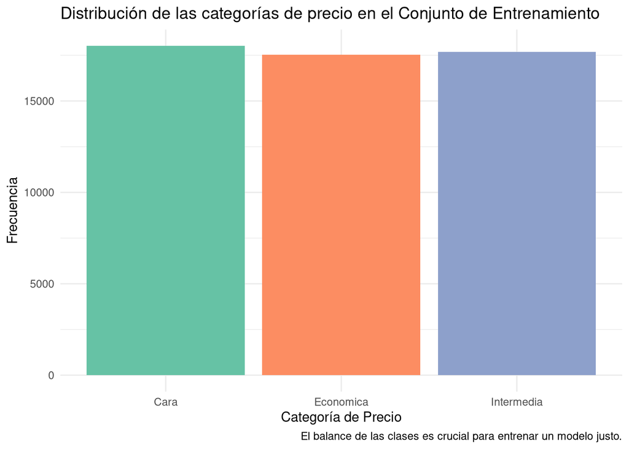

Para esta segunda parte, dividimos todas las propiedades disponibles en dos grupos distintos, aplicando exactamente la misma regla que hemos usado durante toda la consultoría. Tomamos el setenta por ciento de los datos para formar nuestro grupo de aprendizaje y separamos el treinta por ciento restante para poner a prueba el modelo más adelante. Mantener estos grupos idénticos a los laboratorios anteriores es fundamental. Al hacerlo, garantizamos que las evaluaciones sean totalmente justas; todos los métodos que analicemos habrán aprendido de las mismas casas y enfrentarán el mismo examen final. De esta forma, podemos estar seguros de que cualquier mejora en los resultados se debe a que el modelo de regresión logística es mejor, y no a que tuvo datos más fáciles de predecir.